# 2. Tutorial 2

2023-07-04

> [*Back to content page*](https://flatter11.github.io/6040/)

# Background

**Influenza vaccine effectiveness: addressing missing data by multiple imputation**

An observational study investigated the effect of influenza vaccination on influenza infection in the general population. To estimate the vaccine effect, potential confounding effects and effect modification will be considered. Data are available from 2000 adults aged 20 to 60y (saved in ‘fluvaccine.csv’), with the following variables:

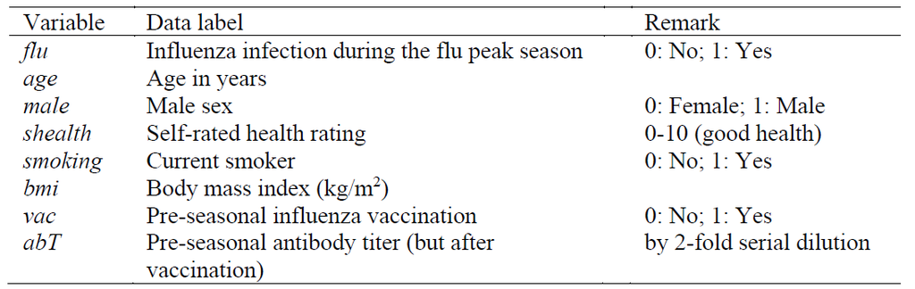

# Complete dataset

## CCA

Complete case analysis

1. Read the dataset into R. Suppose that based on literature review and a preliminary analysis, the causal structure can be summarized by the following DAG:

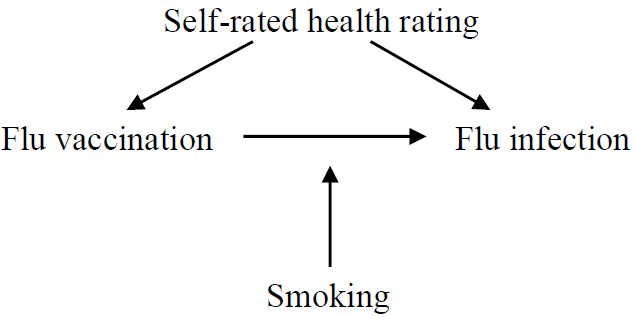

Fit the above regression model and summarize the results in a table.

Answer

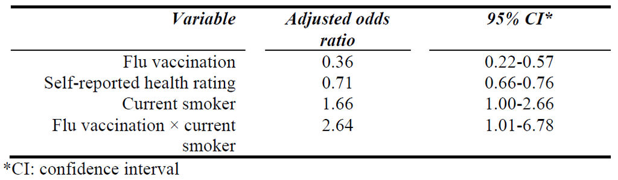

```r
rm(list=ls())
flu <- read.csv("Data/fluvaccine.csv")

lr0 <- glm(flu~vac+shealth+vac*smoking, data=flu, family=binomial) #binomial outcome
cbind(exp(coef(lr0)),exp(confint(lr0))) #take exponential
```

```
##                           2.5 %    97.5 %
## (Intercept) 0.7699386 0.5232756 1.1263231
## vac         0.3631373 0.2232483 0.5675154
## shealth     0.7079997 0.6601779 0.7581005
## smoking     1.6616995 1.0019797 2.6637564
## vac:smoking 2.6444320 1.0069291 6.7800337
```

# Missing dataset (MCAR)

## a Study missingness

Dataset with missing data (MCAR)

2. Suppose the same dataset have some missing data (‘fluvaccine_m1.csv’). Study the dataset especially on the missingness of the data.
1. `aggr()`  
   Calculate or plot the amount of missing/imputed values in each variable and the amount of missing/imputed values in certain combinations of variables
2. `marginplot()`  
   In addition to a standard scatterplot, information about missing/imputed values is shown in the plot margins. Furthermore, imputed vlaues are highlighted in the scatterplot.
3. `complete.cases()`  
   Return a logcial vector indicating which cases are complte, i.e. have no missing values.

Answer

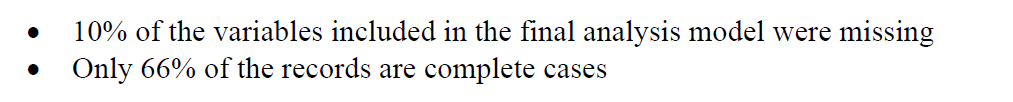

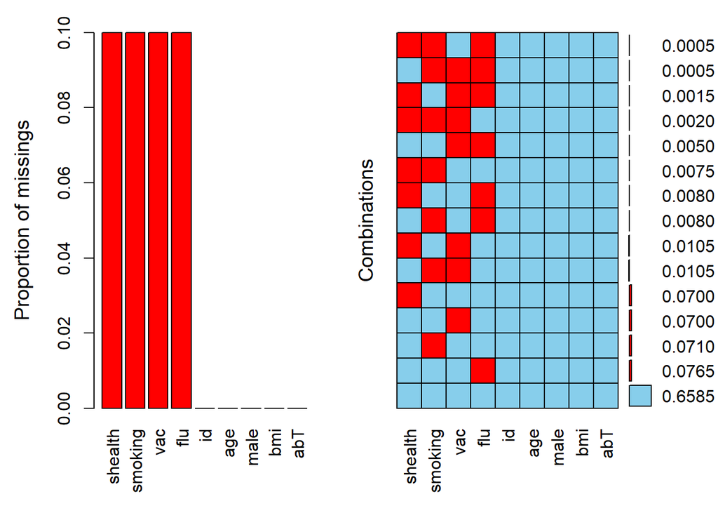

```r
flu.m1 <- read.csv('Data/fluvaccine_m1.csv')

## Summary function
summary(flu.m1) # missing data in shealth, smoking, vac and flu => see NA in these variables indicating missingness

## 1 Visualize missing pattern `aggr()`
require(VIM)
aggr_plot <- aggr(flu.m1, sortVars=T, numbers=T)
```

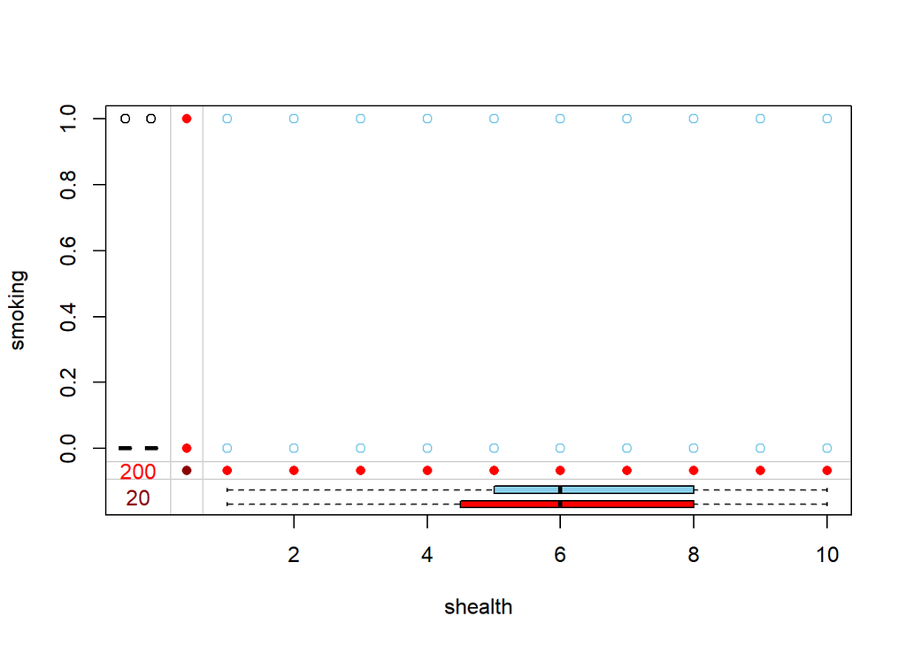

```r
#If no “sortvars=T”, it will not sort variables by number of missingness
#LHS: 4 variable hv 10% missing; RHS graph means the missingness of combination of variables where blue cell means complete data;

## 2 Visualize missing pattern `marginplot()`
#colnames(flu.m1) to check variable names

marginplot(flu.m1[,c(4,5)]) # shealth and smoking
```

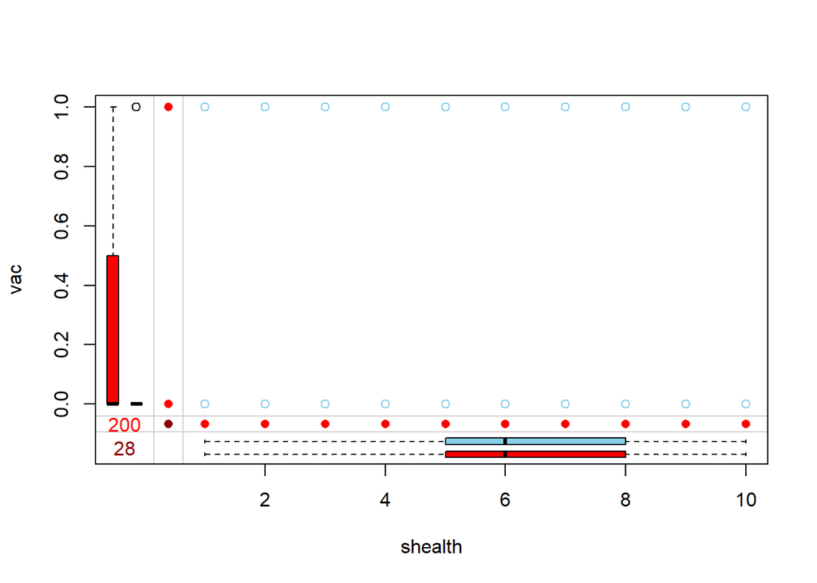

```r
#Margin plot for 4th and 5th variables)
#=> note boxplot for complete data (blue) and missing data (red) for self rated health
#=> only 0 and 1 for smoking so can't see anything
quantile(flu.m1$shealth[is.na(flu.m1$smoking)],na.rm=T) #range of self rated health with smoking missing
quantile(flu.m1$shealth[!is.na(flu.m1$smoking)],na.rm=T) #range of self rated health with smoking not missing
#Can see that median are the same but not IQR — consistent with the box plot

marginplot(flu.m1[,c(4,7)]) # shealth and vac
```

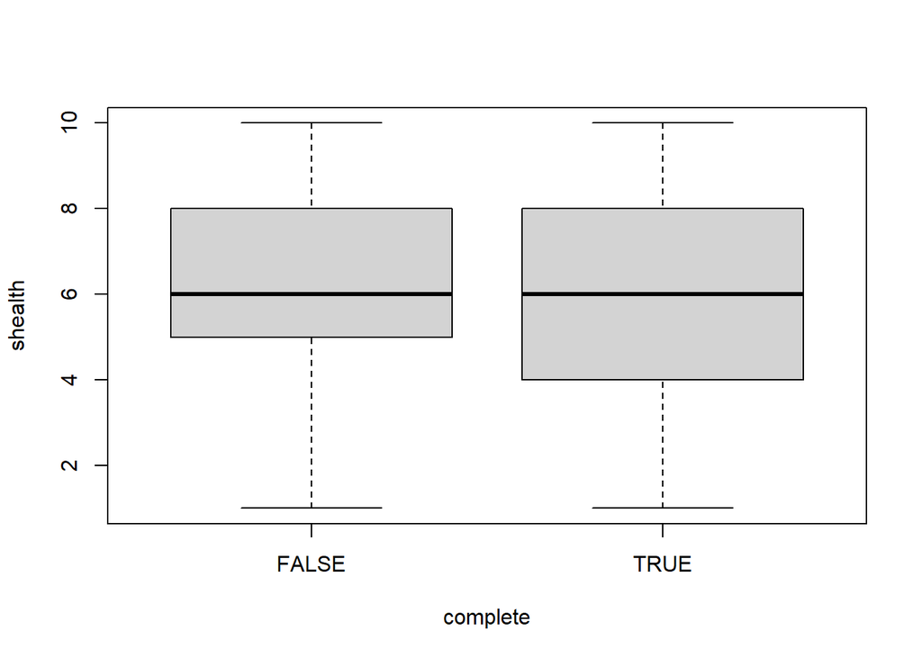

```r
#Self rated health score is exactly the same shown from box-plot
#Vaccination status is binomial,  and no box plot is formed if large enough dataset that data located on either 1 or 0.
#Thus a weird  box-plot formed for missing data coz only 10% missingness (not enough dataset). None for complete data (enough dataset). This is shown in quantile too.
quantile(flu.m1$vac[is.na(flu.m1$shealth)],na.rm=T)
quantile(flu.m1$vac[!is.na(flu.m1$shealth)],na.rm=T)

## 3 Return T and F abt missingness `complete.cases()`
flu.m1$complete <- complete.cases(flu.m1)
head(flu.m1) #False is when there is missing data, e.g. the first row
prop.table(table(flu.m1$complete)) # 66% of the records are complete cases

#Box plot for continuous variable; Proportion table for discrete variable
boxplot(shealth~complete, data=flu.m1) #Distribution of self rated health in complete and missing data is quite similar
```

```r
with(flu.m1, prop.table(table(vac, complete),2)) #2 = by column. Distribution of vaccination status in complete and missing data also quite similar
#fisher.test(with(flu.m1, table(vac, complete)))
with(flu.m1, prop.table(table(smoking, complete),2))
#fisher.test(with(flu.m1, table(smoking, complete)))
```

```
##        id              age             male           shealth
##  Min.   :   1.0   Min.   :20.00   Min.   :0.0000   Min.   : 1.000
##  1st Qu.: 500.8   1st Qu.:30.00   1st Qu.:0.0000   1st Qu.: 5.000
##  Median :1000.5   Median :40.00   Median :1.0000   Median : 6.000
##  Mean   :1000.5   Mean   :40.15   Mean   :0.5015   Mean   : 5.936
##  3rd Qu.:1500.2   3rd Qu.:50.00   3rd Qu.:1.0000   3rd Qu.: 8.000
##  Max.   :2000.0   Max.   :60.00   Max.   :1.0000   Max.   :10.000
##                                                    NA's   :200
##     smoking            bmi             vac              abT
##  Min.   :0.0000   Min.   :15.60   Min.   :0.0000   Min.   :   4.0
##  1st Qu.:0.0000   1st Qu.:24.30   1st Qu.:0.0000   1st Qu.:  64.0
##  Median :0.0000   Median :27.00   Median :0.0000   Median : 128.0
##  Mean   :0.1056   Mean   :27.01   Mean   :0.2294   Mean   : 266.5
##  3rd Qu.:0.0000   3rd Qu.:29.70   3rd Qu.:0.0000   3rd Qu.: 256.0
##  Max.   :1.0000   Max.   :41.20   Max.   :1.0000   Max.   :4096.0
##  NA's   :200                      NA's   :200
##       flu
##  Min.   :0.0
##  1st Qu.:0.0
##  Median :0.0
##  Mean   :0.1
##  3rd Qu.:0.0
##  Max.   :1.0
##  NA's   :200
##
##  Variables sorted by number of missings:
##  Variable Count
##   shealth   0.1
##   smoking   0.1
##       vac   0.1
##       flu   0.1
##        id   0.0
##       age   0.0
##      male   0.0
##       bmi   0.0
##       abT   0.0
##    0%   25%   50%   75%  100%
##  1.00  4.75  6.00  8.00 10.00
##   0%  25%  50%  75% 100%
##    1    5    6    8   10
##   0%  25%  50%  75% 100%
## 0.00 0.00 0.00 0.25 1.00
##   0%  25%  50%  75% 100%
##    0    0    0    0    1
##   id age male shealth smoking  bmi vac abT flu complete
## 1  1  24    0       6      NA 23.1   0 128   0    FALSE
## 2  2  27    1      NA       0 23.7   0 256   0    FALSE
## 3  3  45    1       8       0 26.2   0  64   0     TRUE
## 4  4  44    1       5       0 34.7   1 256  NA    FALSE
## 5  5  22    1       8       0 29.8   0 128   0     TRUE
## 6  6  48    1       2       0 30.9   1 512   0     TRUE
##
##  FALSE   TRUE
## 0.3415 0.6585
##    complete
## vac     FALSE      TRUE
##   0 0.7681159 0.7714503
##   1 0.2318841 0.2285497
##        complete
## smoking     FALSE      TRUE
##       0 0.8902692 0.8959757
##       1 0.1097308 0.1040243
```

## b CCA

Complete case analysis

3. It was known that missingness was completely random (MCAR). Carry out a complete case analysis and compare the results with that in (a).

Answer

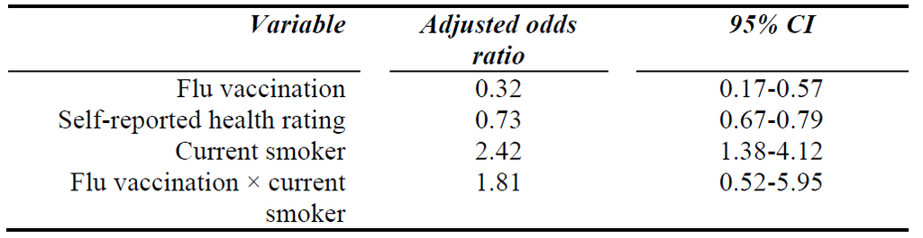

```r
lr0.m1 <- glm(flu~vac+shealth+vac*smoking, data=flu.m1, family=binomial) #note 683 observations deleted
summary(lr0.m1)

cbind(exp(coef(lr0.m1)),exp(confint(lr0.m1)))
```

```
##
## Call:
## glm(formula = flu ~ vac + shealth + vac * smoking, family = binomial,
##     data = flu.m1)
##
## Deviance Residuals:
##     Min       1Q   Median       3Q      Max
## -1.2160  -0.4912  -0.3634  -0.2672   2.7729
##
## Coefficients:
##             Estimate Std. Error z value Pr(>|z|)
## (Intercept) -0.47808    0.24160  -1.979 0.047843 *
## vac         -1.13821    0.31456  -3.618 0.000296 ***
## shealth     -0.31521    0.04319  -7.298 2.91e-13 ***
## smoking      0.88361    0.27830   3.175 0.001498 **
## vac:smoking  0.59455    0.61644   0.964 0.334800
## ---
## Signif. codes:  0 '***' 0.001 '**' 0.01 '*' 0.05 '.' 0.1 ' ' 1
##
## (Dispersion parameter for binomial family taken to be 1)
##
##     Null deviance: 844.34  on 1316  degrees of freedom
## Residual deviance: 766.92  on 1312  degrees of freedom
##   (683 observations deleted due to missingness)
## AIC: 776.92
##
## Number of Fisher Scoring iterations: 5
##
##                           2.5 %    97.5 %
## (Intercept) 0.6199753 0.3835472 0.9903665
## vac         0.3203935 0.1656192 0.5737001
## shealth     0.7296339 0.6696329 0.7933621
## smoking     2.4196216 1.3763984 4.1172714
## vac:smoking 1.8122176 0.5170376 5.9458702
```

## ci MI: Construct dataset + check whether imputed sensibly

Construct imputed dataset using variables in the final analysis model

4. To deal with missing data, multiple imputation method will be used. Create the imputed datasets (say, 50 imputations), based on the variables in the final analysis model. Assess if the variables were imputed sensibly by examining the imputed variables and comparing them with the original dataset.

```r
### Multiple imputation
require(Hmisc)
## Transcan
set.seed(111) #so that output is reproducible in future
flu.m1.impute <- transcan(~flu+vac+shealth+smoking, n.impute=50,
                          shrink=T, data=flu.m1, imputed=T)
```

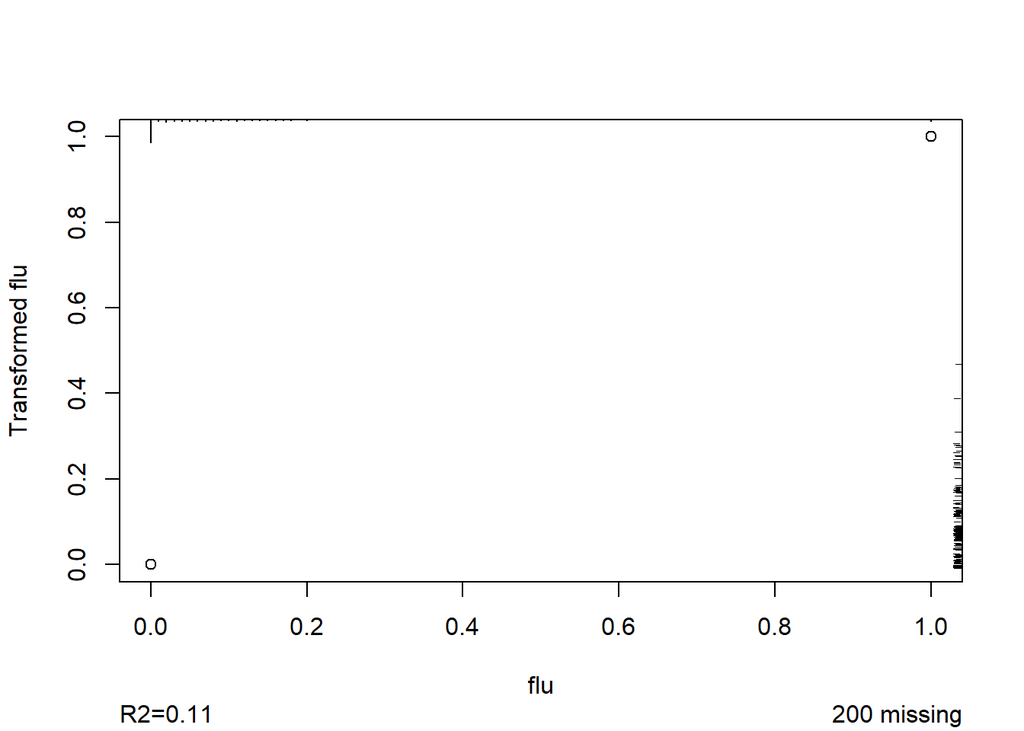

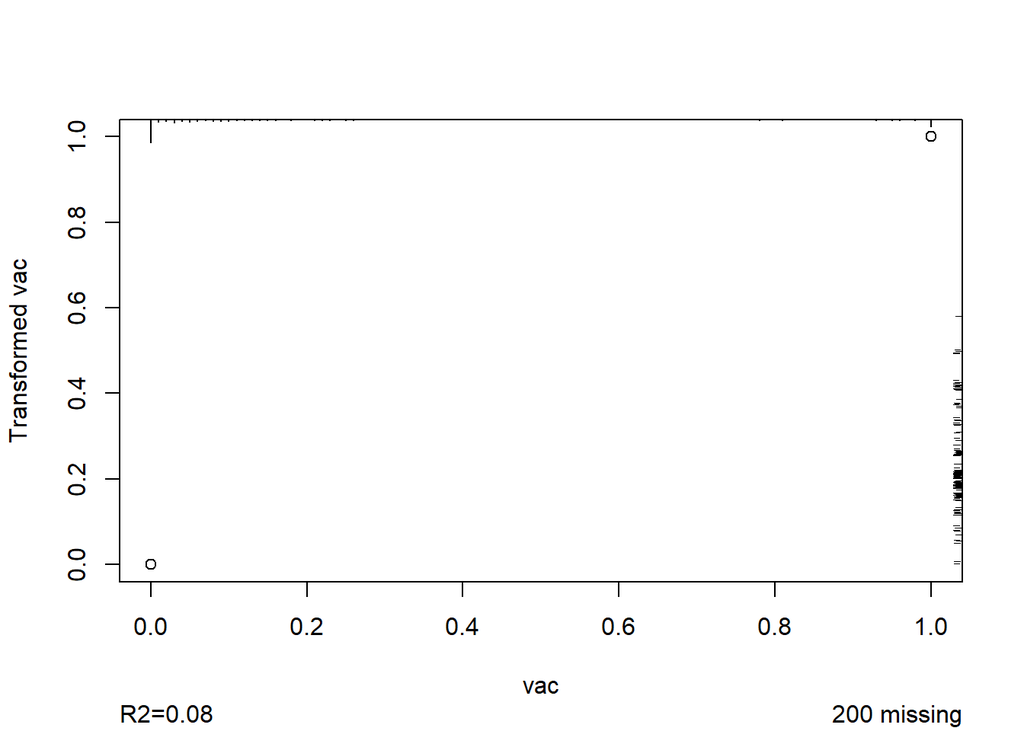

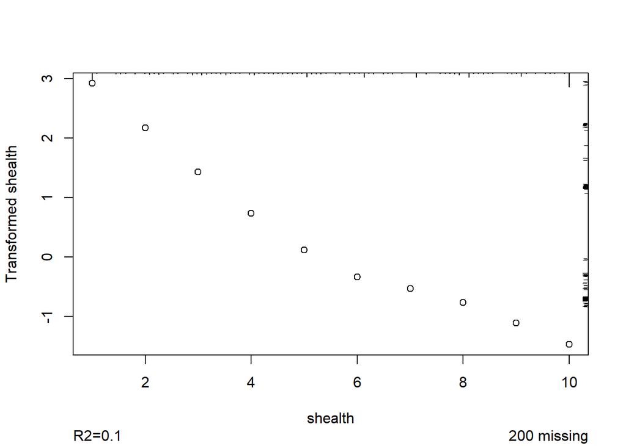

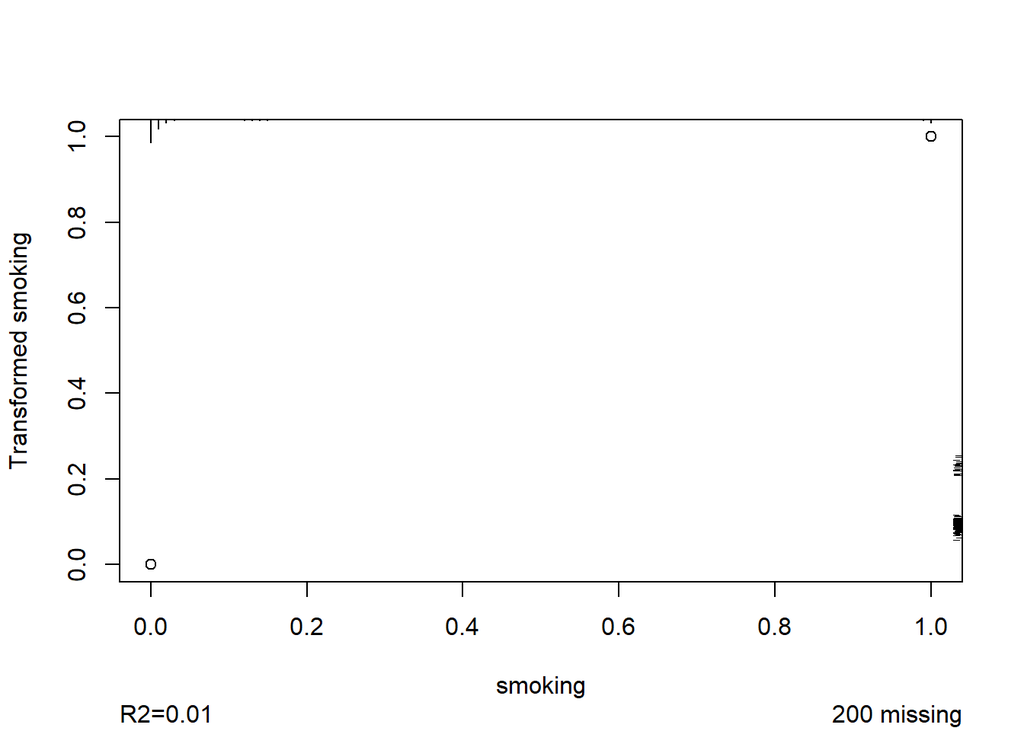

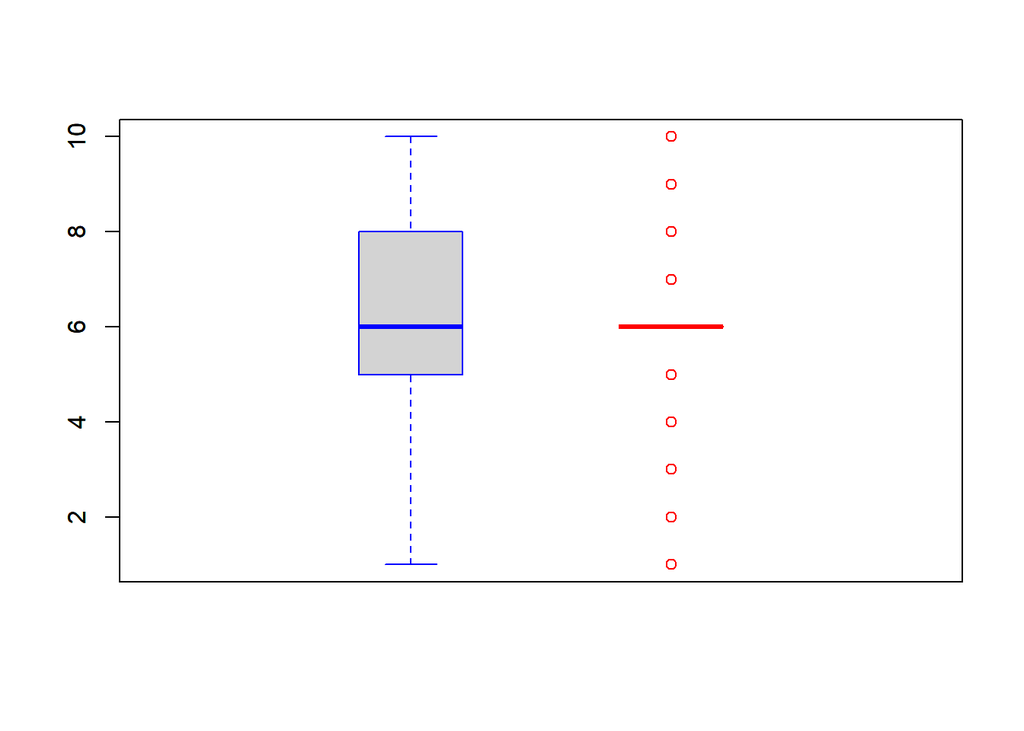

```r
flu.m1.impute$imputed$shealth[,1] #1st imputed dataset (50 in total) showing shealth
flu.m1.impute$imputed$vac[,1]

## Switch to aregImpute
set.seed(11)
flu.m1.impute <- aregImpute(~flu+vac+shealth+smoking, n.impute=50, data=flu.m1)
flu.m1.impute$imputed$shealth[,1]
flu.m1.impute$imputed$vac[,1]

### Visualize imputed data
## shealth (numeric variable)
boxplot(flu.m1$shealth, border='blue', at=1, xlim=c(0,3)) #distribution of origianl dataset shealth
boxplot(flu.m1.impute$imputed$shealth[,1], border='red', at=2, add=T) #distribution of 1st imputed dataset shealth
```

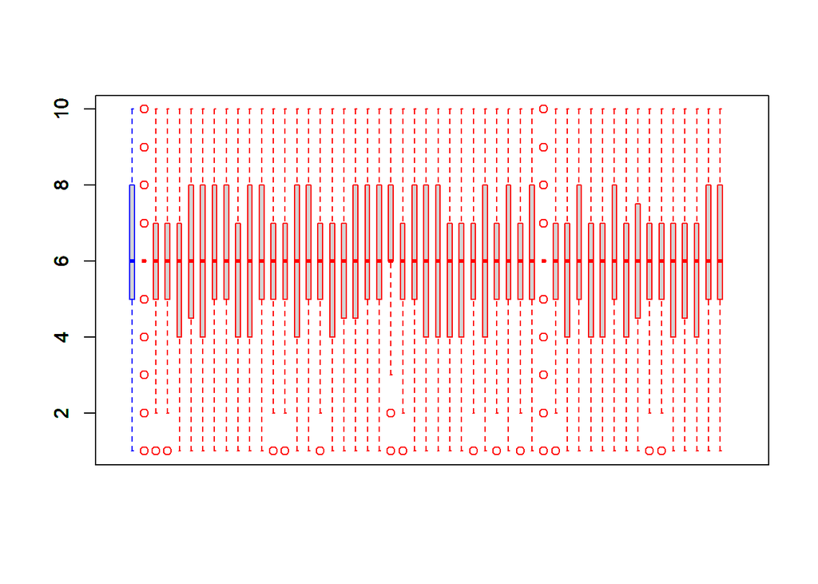

```r
boxplot(flu.m1$shealth, border='blue', at=1, xlim=c(0,53))
for (i in 1:50) boxplot(flu.m1.impute$imputed$shealth[,i], border='red', at=i+1, add=T) #distribution of 50 imputed dataset shealth
```

```r
#The median and IQR are quite similar (compare blue and red)

## vac (categorical)
prop.table(table(flu.m1$vac))
prop.table(table(flu.m1.impute$imputed$vac[,1]))
for(i in 1:50) print(prop.table(table(flu.m1.impute$imputed$vac[,i])))
#Porportion of vaccination didn't fluctuate a lot, quite similar (~23%)
```

```
## Convergence criterion:1.332 0.305 0.082 0.022
## Convergence in 5 iterations
## R-squared achieved in predicting each variable:
##
##     flu     vac shealth smoking
##   0.106   0.079   0.104   0.010
##
## Adjusted R-squared:
##
##     flu     vac shealth smoking
##   0.104   0.077   0.101   0.008
##
## Shrinkage factors:
##
##     flu     vac shealth smoking
##   1.017   1.024   1.026   1.281
##         2        22        23        49        64        73        76        87
##  9.049647  4.372047  1.000000  3.471131  8.690439  2.055071  1.741429 10.000000
##        95       102       103       116       134       146       147       166
##  1.000000  9.049647  2.042155  3.025685  4.681827 10.000000 10.000000  7.445454
##       167       183       187       188       193       195       204       206
##  3.962068 10.000000  1.290406  4.029222  9.544155 10.000000  6.043852  2.889603
##       229       231       240       252       259       304       308       311
##  4.545437  2.706638  1.000000  3.278169  8.899995 10.000000  1.655300  4.029222
##       313       335       336       341       345       376       392       397
##  8.059937  8.493719 10.000000  7.076617 10.000000  6.284014  7.722866  2.020615
##       421       449       454       467       488       489       499       503
##  2.024219  3.528675  9.332832  6.090242  3.615776  3.402757  6.090242  2.201835
##       506       515       545       558       559       566       581       589
##  3.761255 10.000000  7.036554  4.372047  7.650755  1.000000  7.076617  8.761520
##       616       637       644       648       649       650       658       677
##  7.872658  9.881274  7.076617 10.000000 10.000000  6.238619  3.642315  8.024417
##       708       717       718       738       741       754       758       765
## 10.000000  1.000000  1.160831  5.790026 10.000000 10.000000  3.025685  5.045284
##       768       779       812       835       844       848       851       852
## 10.000000  6.928872  5.039527 10.000000  3.471131  5.039527  4.659195  4.232738
##       854       861       875       887       896       898       906       916
##  5.312787  9.049647  8.080815  8.929533  5.835801  6.460519  1.151967 10.000000
##       917       924       937       959       977      1004      1009      1015
## 10.000000 10.000000  2.726664 10.000000  3.276510  7.513636  3.135897  7.870735
```

[output cut: 340 more lines]

```
##
##     0     1
## 0.775 0.225
##
##    0    1
## 0.76 0.24
##
##     0     1
## 0.745 0.255
##
##    0    1
## 0.77 0.23
##
##    0    1
## 0.78 0.22
```

## cii Combine estimate

Fit regression model on imputed datasets

5. Perform the regression analysis using multiple imputation method. Compare your results with that in (c).

Answer

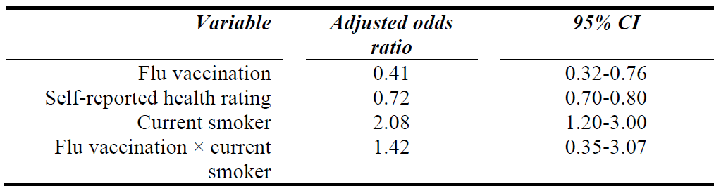

```r
lr0.m1.impute <- fit.mult.impute(flu~vac+shealth+vac*smoking, fitter=glm,
                                 flu.m1.impute, data=flu.m1,family="binomial")
summary(lr0.m1.impute)

cbind(exp(coef(lr0.m1.impute)),exp(confint(lr0.m1.impute)))
#95%CI for CCA (part c) is wider than multiple imputation (part e) coz CCA ignore all missing data
```

# Missing dataset (not MCAR)

## a Study missingness

6. Suppose the same dataset have data not missing completely at random (not MCAR, in ‘fluvaccine_m2.csv’). Study the dataset especially on the missingness of the data.

Answer

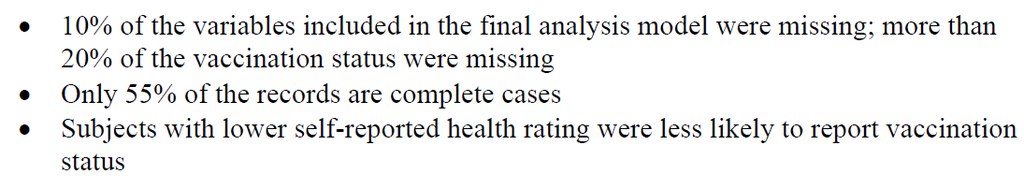

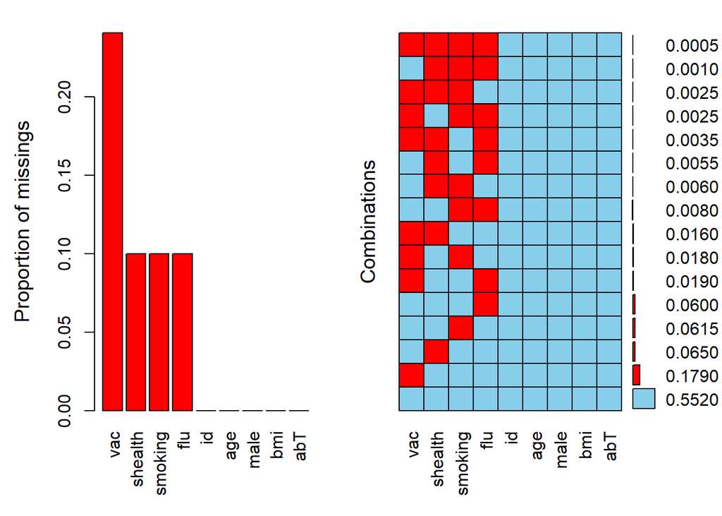

```r
flu.m2 <- read.csv('Data/fluvaccine_m2.csv')

aggr_plot <- aggr(flu.m2, sortVars=T, numbers=T)
```

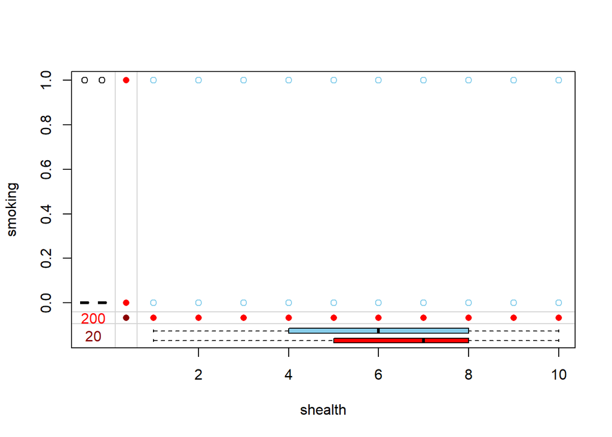

```r
#Vaccination has >20% missigness, there are also increased proportion of missing data in different combination of variables

#head(flu.m2)
marginplot(flu.m2[,c(4,5)]) #shealth a little bit higher for those with missing in smoking
```

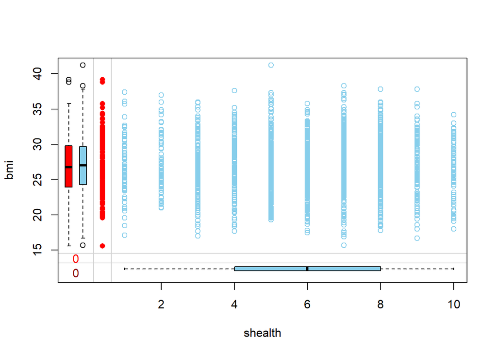

```r
marginplot(flu.m2[,c(4,6)]) #bmi similar for those missing bmi or not; no red box for shealth coz bmi is complete
```

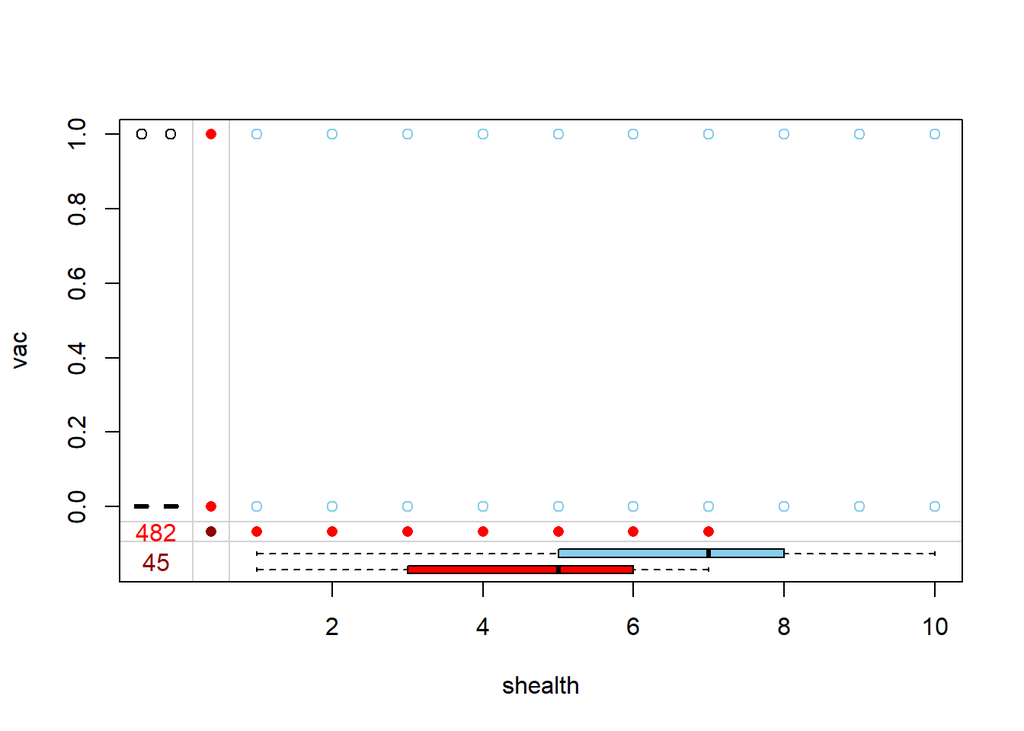

[output not shown]

```r
marginplot(flu.m2[,c(4,7)]) #PROBLEMATIC -- shealth is lower if missing vaccination status (not MCAR)
```

## b CCA

Complete case analysis

7. Carry out a complete case analysis and comparing the results with that in (a).

Answer

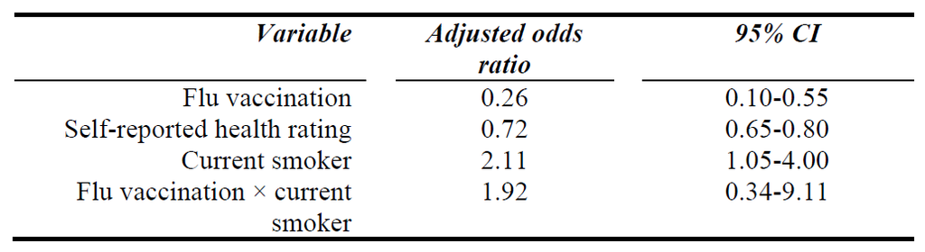

```r
lr0.m2 <- glm(flu~vac+shealth+vac*smoking, data=flu.m2, family=binomial)
summary(lr0.m2)

cbind(exp(coef(lr0.m2)),exp(confint(lr0.m2)))
#CI wider than part c coz more data missing
```

```
##
## Call:
## glm(formula = flu ~ vac + shealth + vac * smoking, family = binomial,
##     data = flu.m2)
##
## Deviance Residuals:
##     Min       1Q   Median       3Q      Max
## -1.1843  -0.4321  -0.3224  -0.2564   2.9643
##
## Coefficients:
##             Estimate Std. Error z value Pr(>|z|)
## (Intercept) -0.40527    0.30513  -1.328  0.18412
## vac         -1.35622    0.41593  -3.261  0.00111 **
## shealth     -0.32746    0.05159  -6.347 2.19e-10 ***
## smoking      0.74894    0.33826   2.214  0.02682 *
## vac:smoking  0.65281    0.81831   0.798  0.42501
## ---
## Signif. codes:  0 '***' 0.001 '**' 0.01 '*' 0.05 '.' 0.1 ' ' 1
##
## (Dispersion parameter for binomial family taken to be 1)
##
##     Null deviance: 633.33  on 1103  degrees of freedom
## Residual deviance: 578.93  on 1099  degrees of freedom
##   (896 observations deleted due to missingness)
## AIC: 588.93
##
## Number of Fisher Scoring iterations: 6
##
##                           2.5 %    97.5 %
## (Intercept) 0.6667985 0.3630119 1.2038925
## vac         0.2576325 0.1043236 0.5450025
## shealth     0.7207520 0.6505433 0.7966769
## smoking     2.1147582 1.0517237 3.9996718
## vac:smoking 1.9209241 0.3401031 9.1136554
```

## c MI: Construct dataset + check whether imputeded sensibly + combine estimate

Multiple imputation using variables in the final model

8. Perform the regression analysis using multiple imputation method. Compare your results with those in (c) and (g).

Answer

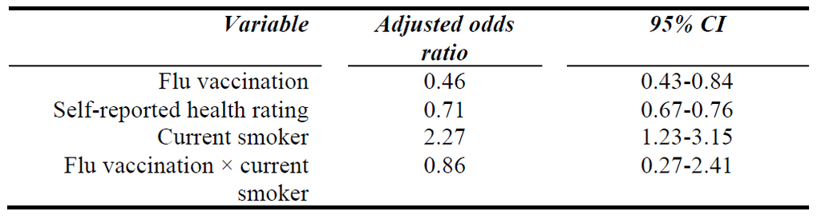

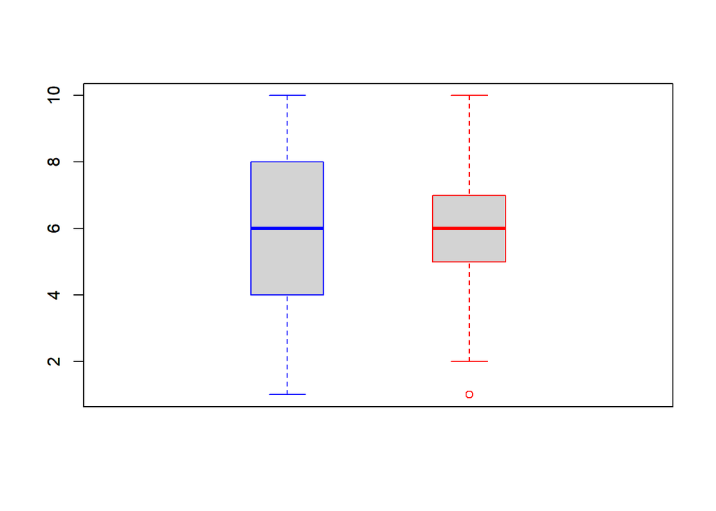

```r
### Multiple imputation
## aregImpute
set.seed(1)
flu.m2.impute <- aregImpute(~flu+vac+shealth+smoking, n.impute=50, data=flu.m2)
flu.m2.impute$imputed$vac

### Visualize imputed data
## shealth
boxplot(flu.m2$shealth, border='blue', at=1, xlim=c(0,3)) #distribution of origianl dataset shealth
boxplot(flu.m2.impute$imputed$shealth[,1], border='red', at=2, add=T) #distribution of 1st imputed dataset shealth
```

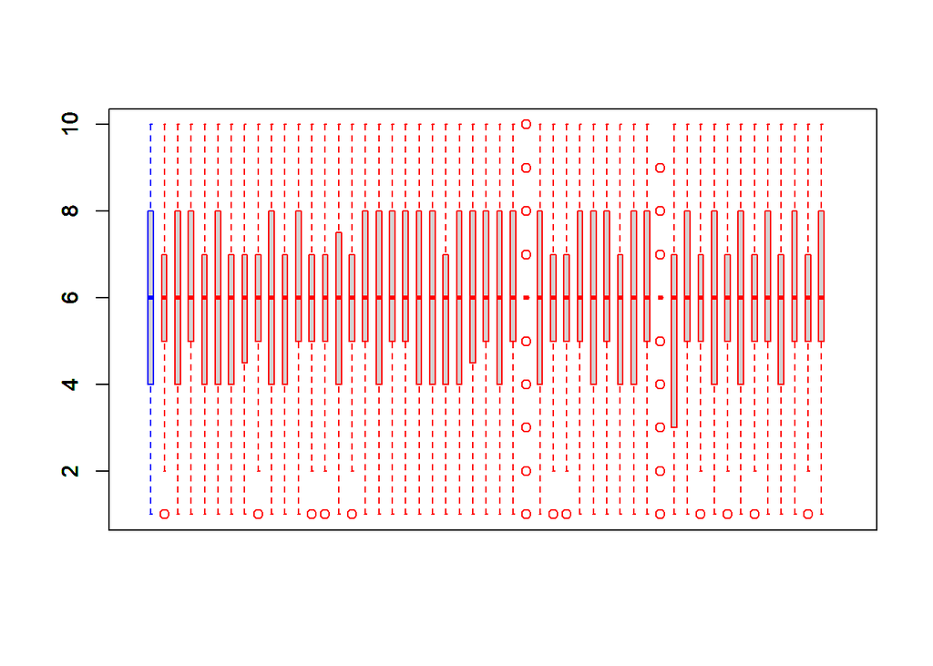

```r
boxplot(flu.m2$shealth, border='blue', at=1, xlim=c(0,53))
for (i in 1:50) boxplot(flu.m2.impute$imputed$shealth[,i], border='red', at=i+1, add=T) #distribution of 50 imputed dataset shealth
```

```r
#Imputation is reasonable

## vac
prop.table(table(flu$vac))
prop.table(table(flu.m2$vac))
prop.table(table(flu.m2.impute$imputed$vac[,1])) #propotion of vaccination in 1st imputed dataset
for(i in 1:50) print(prop.table(table(flu.m2.impute$imputed$vac[,i]))) #propotion of vaccination in 50 imputed dataset

### Comparing the distribution of vaccination for different shealth score, original vs imputed dataset -- skipped in lecture
#distribution of vaccination for different shealth score in original dataset
prop.table(table(flu.m2$shealth, flu.m2$vac),1)

#distribution of vaccination for different shealth score in imputed dataset
vac.miss.m2 <- which(is.na(flu.m2$vac)) #which vac is missing
shealth.miss.m2 <- which(is.na(flu.m2$shealth)) #which shealth is missing
imputed.shealth.m2.i1 <- flu.m2$shealth #copy shealth column
imputed.shealth.m2.i1[shealth.miss.m2] <- flu.m2.impute$imputed$shealth[,1] #replace missing shealth with shealth from 1st imputed dataset
prop.table(table(imputed.shealth.m2.i1[vac.miss.m2], flu.m2.impute$imputed$vac[,1]),1) #shealth where vac is missing AGAINST vac from 1st imputed dataset
```

```
## Iteration 1
Iteration 2
Iteration 3
Iteration 4
Iteration 5
Iteration 6
Iteration 7
Iteration 8
Iteration 9
Iteration 10
Iteration 11
Iteration 12
Iteration 13
Iteration 14
Iteration 15
```

[output cut: 2153 more lines]

```r
lr0.m2.impute <- fit.mult.impute(flu~vac+shealth+vac*smoking, glm,
                                 flu.m2.impute, data=flu.m2, family=binomial)
summary(lr0.m2.impute)

cbind(exp(coef(lr0.m2.impute)),exp(confint(lr0.m2.impute)))
#95%CI is narrower compared to CCA
```

## d MI using more(all) variables

Uing all variables for imputation

1. Suppose we make use of all available variables to create the imputed datasets. Perform the regression analysis and compare your results with those in (c), (g) and (h).

Answer

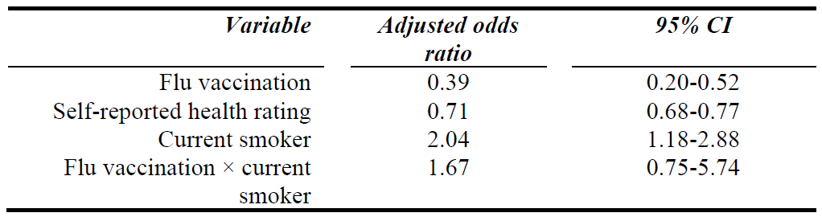

```r
### Multiple imputation
set.seed(704)
flu.m2.impute2 <- aregImpute(~flu+vac+shealth+smoking+age+male+bmi+abT,
                             n.impute=50, data=flu.m2)
flu.m2.impute2$imputed$vac
```

```
## Iteration 1
Iteration 2
Iteration 3
Iteration 4
Iteration 5
Iteration 6
Iteration 7
Iteration 8
Iteration 9
Iteration 10
Iteration 11
Iteration 12
Iteration 13
Iteration 14
Iteration 15
```

[output cut: 1970 more lines]

```r
lr0.m2.impute2 <- fit.mult.impute(flu ~vac+shealth+vac*smoking, glm,
                                  flu.m2.impute2, data=flu.m2, family=binomial)
summary(lr0.m2.impute2)

cbind(exp(coef(lr0.m2.impute2)),exp(confint(lr0.m2.impute2)))
```

## Interpretation of results

- The estimate for “flu vaccination × current smoker” is consistent in CCA (b) and MI with more variables (d), therefore, MI with more variables (d) is more reliable than MI (c).

# Missing dataset (high missingness)

## a Study missingness

10. Suppose the same dataset have more missing data (up to 30% missing for key variables, ‘fluvaccine_m3.csv’). Study the dataset especially on the missingness of the data

Answer

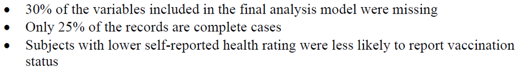

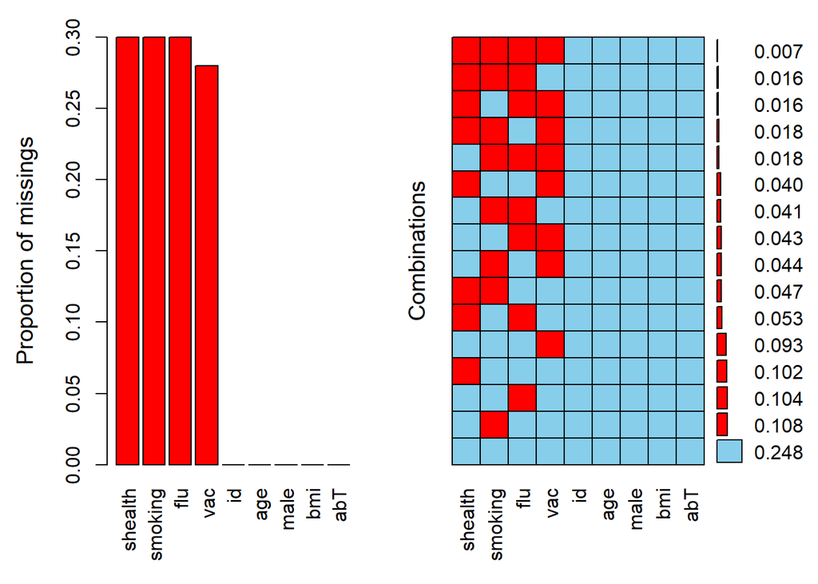

```r
flu.m3 <- read.csv('Data/fluvaccine_m3.csv')

aggr_plot <- aggr(flu.m3, sortVars=T, numbers=T) #Missingness very high, up to 30%
```

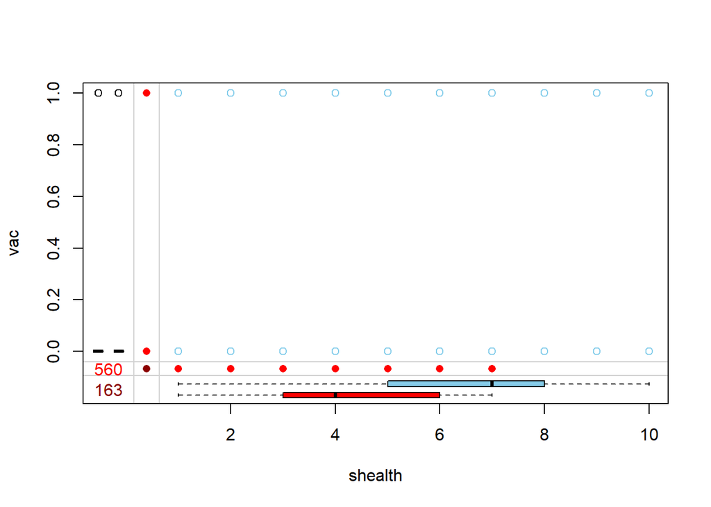

[output not shown]

```r
marginplot(flu.m3[,c(4,7)])
```